# Validación_Balanceo_de_Datos

### Limpieza y configuración del entorno de trabajo

```r
rm(list = ls())
graphics.off()
cat("\014")
```

```r
options(scipen = 999)
options(digits = 3)
```

#### Descripción de los datos

Transacciones realizadas con tarjetas de crédito en septiembre de 2013 por titulares de tarjetas europeos.  
La finalidad es la detección de fraude con tarjetas de crédito del banco XXX. Como la  
información es privada, no sabemos realmente qué significan las características y están  
nombradas como V1, V2, V3, etc., excepto por las columnas Time y Amount (el importe de  
la transacción). Nuestras clases son 0 y 1, correspondiendo a “Transacción Normal” y “Hubo Fraude”, respectivamente

### Lectura de la data

```r
datos.a <- read.csv("creditcard.csv",
                    stringsAsFactors = T,
                    sep = ",")
head(datos.a)
```

```
##   Time     V1      V2    V3     V4      V5      V6      V7      V8     V9
## 1    0 -1.360 -0.0728 2.536  1.378 -0.3383  0.4624  0.2396  0.0987  0.364
## 2    0  1.192  0.2662 0.166  0.448  0.0600 -0.0824 -0.0788  0.0851 -0.255
## 3    1 -1.358 -1.3402 1.773  0.380 -0.5032  1.8005  0.7915  0.2477 -1.515
## 4    1 -0.966 -0.1852 1.793 -0.863 -0.0103  1.2472  0.2376  0.3774 -1.387
## 5    2 -1.158  0.8777 1.549  0.403 -0.4072  0.0959  0.5929 -0.2705  0.818
## 6    2 -0.426  0.9605 1.141 -0.168  0.4210 -0.0297  0.4762  0.2603 -0.569
##       V10    V11     V12    V13    V14    V15    V16     V17     V18     V19
## 1  0.0908 -0.552 -0.6178 -0.991 -0.311  1.468 -0.470  0.2080  0.0258  0.4040
## 2 -0.1670  1.613  1.0652  0.489 -0.144  0.636  0.464 -0.1148 -0.1834 -0.1458
## 3  0.2076  0.625  0.0661  0.717 -0.166  2.346 -2.890  1.1100 -0.1214 -2.2619
## 4 -0.0550 -0.226  0.1782  0.508 -0.288 -0.631 -1.060 -0.6841  1.9658 -1.2326
## 5  0.7531 -0.823  0.5382  1.346 -1.120  0.175 -0.451 -0.2370 -0.0382  0.8035
## 6 -0.3714  1.341  0.3599 -0.358 -0.137  0.518  0.402 -0.0581  0.0687 -0.0332
##       V20      V21      V22     V23     V24    V25    V26      V27     V28
## 1  0.2514 -0.01831  0.27784 -0.1105  0.0669  0.129 -0.189  0.13356 -0.0211
## 2 -0.0691 -0.22578 -0.63867  0.1013 -0.3398  0.167  0.126 -0.00898  0.0147
## 3  0.5250  0.24800  0.77168  0.9094 -0.6893 -0.328 -0.139 -0.05535 -0.0598
## 4 -0.2080 -0.10830  0.00527 -0.1903 -1.1756  0.647 -0.222  0.06272  0.0615
## 5  0.4085 -0.00943  0.79828 -0.1375  0.1413 -0.206  0.502  0.21942  0.2152
## 6  0.0850 -0.20825 -0.55982 -0.0264 -0.3714 -0.233  0.106  0.25384  0.0811
##   Amount Class
## 1 149.62     0
## 2   2.69     0
## 3 378.66     0
## 4 123.50     0
## 5  69.99     0
## 6   3.67     0
```

```r
dim(datos.a)
```

```
## [1] 284807     31
```

Identificación de tipos de variables

```r
str(datos.a)
```

```
## 'data.frame':    284807 obs. of  31 variables:
##  $ Time  : num  0 0 1 1 2 2 4 7 7 9 ...
##  $ V1    : num  -1.36 1.192 -1.358 -0.966 -1.158 ...
##  $ V2    : num  -0.0728 0.2662 -1.3402 -0.1852 0.8777 ...
##  $ V3    : num  2.536 0.166 1.773 1.793 1.549 ...
##  $ V4    : num  1.378 0.448 0.38 -0.863 0.403 ...
##  $ V5    : num  -0.3383 0.06 -0.5032 -0.0103 -0.4072 ...
##  $ V6    : num  0.4624 -0.0824 1.8005 1.2472 0.0959 ...
##  $ V7    : num  0.2396 -0.0788 0.7915 0.2376 0.5929 ...
##  $ V8    : num  0.0987 0.0851 0.2477 0.3774 -0.2705 ...
##  $ V9    : num  0.364 -0.255 -1.515 -1.387 0.818 ...
##  $ V10   : num  0.0908 -0.167 0.2076 -0.055 0.7531 ...
##  $ V11   : num  -0.552 1.613 0.625 -0.226 -0.823 ...
##  $ V12   : num  -0.6178 1.0652 0.0661 0.1782 0.5382 ...
##  $ V13   : num  -0.991 0.489 0.717 0.508 1.346 ...
```

[output cut: 17 more lines]

#Convirtiendo el target a factor

```r
datos.a$Class <- as.factor(datos.a$Class)
#Ver la distribución de las clases del target
table(datos.a$Class)
```

```
##
##      0      1
## 284315    492
```

```r
round(prop.table(table(datos.a$Class)), 3) * 100
```

```
##
##    0    1
## 99.8  0.2
```

Se observa que hay desbalanceo en los datos

Partición de la data 70-30 para no afectar al testing, solo se balancea la data train

```r
library(caret)
set.seed(123)
index   <- createDataPartition(datos.a$Class,   # Es la variable dependiene
                               p = 0.7, list = FALSE)

imbal_train    <- datos.a[ index, ]  # Base de train no balanceada (70%)
imbal_testing  <- datos.a[-index, ]  # Base de testing (30%
```

Verificación de que la proporción sea la misma en toda la data

```r
# Proporción Base Original NO:99.83% y SI:0.17%
addmargins(table(datos.a$Class))
```

```
##
##      0      1    Sum
## 284315    492 284807
```

```r
round(prop.table(table(datos.a$Class)) * 100, 2)
```

```
##
##     0     1
## 99.83  0.17
```

```r
# Proporción Base train NO:99.83% y SI:0.17%
addmargins(table(imbal_train$Class))
```

```
##
##      0      1    Sum
## 199021    345 199366
```

```r
round(prop.table(table(imbal_train$Class)) * 100, 2)
```

```
##
##     0     1
## 99.83  0.17
```

```r
# Proporción Base Testing NO:99.83% y SI:0.17%
addmargins(table(imbal_testing$Class))
```

```
##
##     0     1   Sum
## 85294   147 85441
```

```r
round(prop.table(table(imbal_testing$Class)) * 100, 2)
```

```
##
##     0     1
## 99.83  0.17
```

### Aplicando métodos de balanceo

```r
#Método Undersampling (under_train)
set.seed(123)
under_train <- downSample(x = imbal_train[, c(1:30)], # predictoras
                          y = imbal_train$Class,      # target
                          yname = "Class") # Nombre columna target

#Validando que se produjo el balanceo en la base de entrenamiento con el
#metodo Undersampling
addmargins(table(under_train$Class))
```

```
##
##   0   1 Sum
## 345 345 690
```

```r
#Método OverSampling (over_train)
set.seed(123)
over_train <- upSample(x = imbal_train[, c(1:30)],
                       y = imbal_train$Class,
                       yname = "Class")
##Validando que se produjo el balanceo en la base de entrenamiento con el
#metodo oversampling
addmargins(table(over_train$Class))
```

```
##
##      0      1    Sum
## 199021 199021 398042
```

```r
#Método SMOTE (smote_train)
library(performanceEstimation)
set.seed(123)
smote_train <- smote(Class ~ .,
                     data = imbal_train,
                     perc.over  = 2,    # SMOTE          (clase minoritaria)
                     perc.under = 1.5)  # Undersampling  (clase mayoritaria)

addmargins(table(imbal_train$Class)) #antes
```

```
##
##      0      1    Sum
## 199021    345 199366
```

```r
addmargins(table(smote_train$Class)) #despues
```

```
##
##    0    1  Sum
## 1035 1035 2070
```

```r
# Método de Validación Cruzada con k = 10 para todos los modelos

ctrl <- trainControl(method = "cv", number = 10)
```

### Aplicando Modelo Regresión logística

```r
#Modelo con los datos originales (desbalanceados)
set.seed(123)
modelo_imbal <- train(Class ~ ., data = imbal_train, method = "glm",
                      family = "binomial", trControl = ctrl, metric = "Accuracy")
modelo_imbal
```

```
## Generalized Linear Model
##
## 199366 samples
##     30 predictor
##      2 classes: '0', '1'
##
## No pre-processing
## Resampling: Cross-Validated (10 fold)
## Summary of sample sizes: 179428, 179429, 179430, 179430, 179430, 179430, ...
## Resampling results:
##
##   Accuracy  Kappa
##   0.999     0.769
```

```r
summary(modelo_imbal)
```

```
##
## Call:
## NULL
##
## Deviance Residuals:
##    Min      1Q  Median      3Q     Max
## -5.341  -0.027  -0.018  -0.012   4.663
##
## Coefficients:
##                Estimate  Std. Error z value             Pr(>|z|)
## (Intercept) -8.56113451  0.32144939  -26.63 < 0.0000000000000002 ***
## Time        -0.00000297  0.00000284   -1.04              0.29618
## V1           0.11928110  0.05553650    2.15              0.03173 *
## V2           0.00849166  0.07232745    0.12              0.90654
## V3           0.01739734  0.06775582    0.26              0.79736
## V4           0.72764718  0.09451553    7.70    0.000000000000014 ***
## V5           0.14238592  0.08189179    1.74              0.08209 .
## V6          -0.08371149  0.08999880   -0.93              0.35230
## V7          -0.11802137  0.08560162   -1.38              0.16798
## V8          -0.18225027  0.03993884   -4.56    0.000005037153379 ***
## V9          -0.25514478  0.13927301   -1.83              0.06696 .
## V10         -0.91353977  0.12558251   -7.27    0.000000000000348 ***
## V11          0.06476124  0.10105907    0.64              0.52164
## V12          0.00858404  0.10596655    0.08              0.93544
## V13         -0.21918761  0.10024524   -2.19              0.02878 *
## V14         -0.51334241  0.07524349   -6.82    0.000000000008952 ***
## V15         -0.17173047  0.10865225   -1.58              0.11398
## V16         -0.23435581  0.15431741   -1.52              0.12885
## V17         -0.04213043  0.08837367   -0.48              0.63355
## V18          0.00030015  0.15966083    0.00              0.99850
## V19          0.05516070  0.12286602    0.45              0.65347
## V20         -0.49421185  0.11467723   -4.31    0.000016355744676 ***
## V21          0.29671144  0.07776393    3.82              0.00014 ***
## V22          0.43347993  0.16446082    2.64              0.00839 **
## V23         -0.09689787  0.06949586   -1.39              0.16323
## V24          0.15060076  0.18532322    0.81              0.41643
## V25         -0.13326284  0.16713411   -0.80              0.42525
## V26         -0.30755969  0.24946519   -1.23              0.21762
## V27         -0.79926978  0.17232801   -4.64    0.000003516734988 ***
## V28         -0.26951255  0.11128172   -2.42              0.01544 *
## Amount       0.00087322  0.00046353    1.88              0.05959 .
## ---
## Signif. codes:  0 '***' 0.001 '**' 0.01 '*' 0.05 '.' 0.1 ' ' 1
##
## (Dispersion parameter for binomial family taken to be 1)
##
##     Null deviance: 5077.4  on 199365  degrees of freedom
## Residual deviance: 1403.2  on 199335  degrees of freedom
## AIC: 1465
##
## Number of Fisher Scoring iterations: 12
```

```r
#Modelo con los datos balanceados (undersampling)
set.seed(123)
modelo_under  <- train(Class ~ .,
                       data = under_train,
                       method = "glm", family = "binomial",
                       trControl = ctrl,
                       metric = "Accuracy")
modelo_under
```

```
## Generalized Linear Model
##
## 690 samples
##  30 predictor
##   2 classes: '0', '1'
##
## No pre-processing
## Resampling: Cross-Validated (10 fold)
## Summary of sample sizes: 620, 621, 622, 621, 620, 621, ...
## Resampling results:
##
##   Accuracy  Kappa
##   0.935     0.869
```

```r
summary(modelo_under)
```

```
##
## Call:
## NULL
##
## Deviance Residuals:
##     Min       1Q   Median       3Q      Max
## -2.5366  -0.0832   0.0000   0.0000   2.8352
##
## Coefficients:
##                  Estimate    Std. Error z value Pr(>|z|)
## (Intercept)  -23.19530429   93.00387731   -0.25    0.803
## Time          -0.00000658    0.00001042   -0.63    0.528
## V1           -10.04245561   21.14601918   -0.47    0.635
## V2            53.62878169  136.91590125    0.39    0.695
## V3           -48.62769825   54.46889194   -0.89    0.372
## V4            33.53375704   43.86187901    0.76    0.445
## V5           -21.72491268   10.74502293   -2.02    0.043 *
## V6           -25.50403087   62.27386396   -0.41    0.682
## V7          -102.78043804  214.74823727   -0.48    0.632
## V8            20.33757163   36.54122169    0.56    0.578
## V9           -39.82240819   65.84540593   -0.60    0.545
## V10          -91.81239750  151.41903852   -0.61    0.544
## V11           70.29569398  128.22813844    0.55    0.584
## V12         -126.13950466  230.30411411   -0.55    0.584
## V13           -1.22250546    6.06658625   -0.20    0.840
## V14         -134.99224801  251.24388282   -0.54    0.591
## V15           -3.73524510    8.95088558   -0.42    0.676
## V16         -120.19528546  221.69559747   -0.54    0.588
## V17         -213.49192739  389.17126653   -0.55    0.583
## V18          -80.49088074  148.69751908   -0.54    0.588
## V19           30.91957717   61.59944271    0.50    0.616
## V20           -5.15266913   41.83378820   -0.12    0.902
## V21           11.32212546   10.57267115    1.07    0.284
## V22            8.77690837   27.23077468    0.32    0.747
## V23           21.59972738   82.28873467    0.26    0.793
## V24           -3.21353298    7.86104730   -0.41    0.683
## V25           12.62927977   37.47927128    0.34    0.736
## V26            1.76852321    9.48326779    0.19    0.852
## V27           17.60803903   29.66438440    0.59    0.553
## V28           35.66003905   99.79914671    0.36    0.721
## Amount         0.26923071    0.95094937    0.28    0.777
## ---
## Signif. codes:  0 '***' 0.001 '**' 0.01 '*' 0.05 '.' 0.1 ' ' 1
##
## (Dispersion parameter for binomial family taken to be 1)
##
##     Null deviance: 956.54  on 689  degrees of freedom
## Residual deviance: 104.44  on 659  degrees of freedom
## AIC: 166.4
##
## Number of Fisher Scoring iterations: 25
```

```r
#Modelo con los datos balanceados (oversampling)
set.seed(123)
modelo_over    <- train(Class ~ .,
                        data = over_train,
                        method = "glm", family = "binomial",
                        trControl = ctrl,
                        metric = "Accuracy")
modelo_over
```

```
## Generalized Linear Model
##
## 398042 samples
##     30 predictor
##      2 classes: '0', '1'
##
## No pre-processing
## Resampling: Cross-Validated (10 fold)
## Summary of sample sizes: 358237, 358238, 358238, 358238, 358238, 358238, ...
## Resampling results:
##
##   Accuracy  Kappa
##   0.957     0.915
```

```r
summary(modelo_over)
```

```
##
## Call:
## NULL
##
## Deviance Residuals:
##    Min      1Q  Median      3Q     Max
## -8.490  -0.233   0.000   0.000   2.531
##
## Coefficients:
##                 Estimate   Std. Error z value             Pr(>|z|)
## (Intercept) -3.564645898  0.037027315  -96.27 < 0.0000000000000002 ***
## Time        -0.000008815  0.000000271  -32.56 < 0.0000000000000002 ***
## V1           0.568446007  0.015998187   35.53 < 0.0000000000000002 ***
## V2           0.658432499  0.021140393   31.15 < 0.0000000000000002 ***
## V3           0.237301004  0.012481517   19.01 < 0.0000000000000002 ***
## V4           0.797338137  0.008679700   91.86 < 0.0000000000000002 ***
## V5           0.849212480  0.018025435   47.11 < 0.0000000000000002 ***
## V6          -0.462087041  0.012189050  -37.91 < 0.0000000000000002 ***
## V7          -0.445516606  0.021554641  -20.67 < 0.0000000000000002 ***
## V8          -0.437178006  0.008302566  -52.66 < 0.0000000000000002 ***
## V9          -0.149315860  0.011967581  -12.48 < 0.0000000000000002 ***
## V10         -0.679544974  0.014580911  -46.61 < 0.0000000000000002 ***
## V11          0.557622845  0.011885019   46.92 < 0.0000000000000002 ***
## V12         -0.854409600  0.016913040  -50.52 < 0.0000000000000002 ***
## V13         -0.339869791  0.008550717  -39.75 < 0.0000000000000002 ***
## V14         -1.454947790  0.019592353  -74.26 < 0.0000000000000002 ***
## V15         -0.043144888  0.009513737   -4.54     0.00000576009340 ***
## V16         -0.748010738  0.018171704  -41.16 < 0.0000000000000002 ***
## V17         -0.914598385  0.024209096  -37.78 < 0.0000000000000002 ***
## V18         -0.302486417  0.015809669  -19.13 < 0.0000000000000002 ***
## V19          0.308949353  0.012768615   24.20 < 0.0000000000000002 ***
## V20         -0.727802715  0.023773959  -30.61 < 0.0000000000000002 ***
## V21         -0.127506949  0.011054910  -11.53 < 0.0000000000000002 ***
## V22          0.472452914  0.015534461   30.41 < 0.0000000000000002 ***
## V23          0.423508669  0.020197423   20.97 < 0.0000000000000002 ***
## V24         -0.123061054  0.016506627   -7.46     0.00000000000009 ***
## V25         -0.043736783  0.018396682   -2.38                0.017 *
## V26         -0.721921246  0.023009363  -31.38 < 0.0000000000000002 ***
## V27          0.341125032  0.024977824   13.66 < 0.0000000000000002 ***
## V28          0.893190034  0.036978830   24.15 < 0.0000000000000002 ***
## Amount       0.008335390  0.000225116   37.03 < 0.0000000000000002 ***
## ---
## Signif. codes:  0 '***' 0.001 '**' 0.01 '*' 0.05 '.' 0.1 ' ' 1
##
## (Dispersion parameter for binomial family taken to be 1)
##
##     Null deviance: 551803  on 398041  degrees of freedom
## Residual deviance:  98764  on 398011  degrees of freedom
## AIC: 98826
##
## Number of Fisher Scoring iterations: 14
```

```r
#Modelo con los datos balanceados (SMOTE)
set.seed(123)
modelo_smote      <- train(Class ~ .,
                           data = smote_train,
                           method = "glm", family = "binomial",
                           trControl = ctrl,
                           metric = "Accuracy")
modelo_smote
```

```
## Generalized Linear Model
##
## 2070 samples
##   30 predictor
##    2 classes: '0', '1'
##
## No pre-processing
## Resampling: Cross-Validated (10 fold)
## Summary of sample sizes: 1862, 1862, 1864, 1864, 1862, 1864, ...
## Resampling results:
##
##   Accuracy  Kappa
##   0.958     0.917
```

```r
summary(modelo_smote)
```

```
##
## Call:
## NULL
##
## Deviance Residuals:
##    Min      1Q  Median      3Q     Max
## -3.134  -0.107   0.000   0.000   3.103
##
## Coefficients:
##                  Estimate    Std. Error z value Pr(>|z|)
## (Intercept)  -26.80377219   80.73985499   -0.33  0.73991
## Time          -0.00001884    0.00000516   -3.65  0.00026 ***
## V1           -17.86253445   18.17523113   -0.98  0.32571
## V2            73.45181766  118.88244193    0.62  0.53667
## V3           -76.63985275   46.99947184   -1.63  0.10296
## V4            51.68915893   37.96087326    1.36  0.17331
## V5           -37.38284464    8.46645521   -4.42  0.00001 ***
## V6           -36.30844639   54.07480057   -0.67  0.50193
## V7          -151.56458686  186.40352744   -0.81  0.41616
## V8            29.02538886   31.68610019    0.92  0.35965
## V9           -60.75196437   57.09700487   -1.06  0.28732
## V10         -142.01126965  131.30465761   -1.08  0.27946
## V11          107.64124733  111.24967106    0.97  0.33326
## V12         -192.36031044  199.79500394   -0.96  0.33565
## V13           -1.20507785    5.25991776   -0.23  0.81879
## V14         -204.77763995  217.98605935   -0.94  0.34752
## V15           -5.31665140    7.77039846   -0.68  0.49384
## V16         -181.92223670  192.33229355   -0.95  0.34421
## V17         -326.46024153  337.62332045   -0.97  0.33358
## V18         -123.06432289  129.01919892   -0.95  0.34016
## V19           45.16858120   53.46116719    0.84  0.39817
## V20           -3.94272252   36.30390572   -0.11  0.91352
## V21           18.19352442    9.03094771    2.01  0.04395 *
## V22           11.35308367   23.64835208    0.48  0.63117
## V23           28.01998818   71.46055573    0.39  0.69498
## V24           -3.77700188    6.81605273   -0.55  0.57949
## V25           17.21028387   32.53502591    0.53  0.59682
## V26            4.41099612    8.20939354    0.54  0.59105
## V27           29.04460305   25.73567671    1.13  0.25908
## V28           49.33982697   86.61165146    0.57  0.56890
## Amount         0.34420997    0.82583154    0.42  0.67682
## ---
## Signif. codes:  0 '***' 0.001 '**' 0.01 '*' 0.05 '.' 0.1 ' ' 1
##
## (Dispersion parameter for binomial family taken to be 1)
##
##     Null deviance: 2869.63  on 2069  degrees of freedom
## Residual deviance:  365.68  on 2039  degrees of freedom
## AIC: 427.7
##
## Number of Fisher Scoring iterations: 25
```

```r
modelos  <- list(sin_balancear = modelo_imbal,
                 under    = modelo_under,
                 over     = modelo_over,
                 SMOTE    = modelo_smote)
comparacion_modelos <- resamples(modelos)
summary(comparacion_modelos)
```

```
##
## Call:
## summary.resamples(object = comparacion_modelos)
##
## Models: sin_balancear, under, over, SMOTE
## Number of resamples: 10
##
## Accuracy
##                Min. 1st Qu. Median  Mean 3rd Qu.  Max. NA's
## sin_balancear 0.999   0.999  0.999 0.999   0.999 0.999    0
## under         0.899   0.928  0.941 0.935   0.942 0.971    0
## over          0.954   0.956  0.958 0.957   0.958 0.959    0
## SMOTE         0.923   0.948  0.966 0.958   0.970 0.981    0
##
## Kappa
##                Min. 1st Qu. Median  Mean 3rd Qu.  Max. NA's
## sin_balancear 0.711   0.731  0.765 0.769   0.806 0.830    0
## under         0.797   0.855  0.882 0.869   0.884 0.943    0
## over          0.908   0.912  0.916 0.915   0.916 0.919    0
## SMOTE         0.845   0.897  0.932 0.917   0.940 0.961    0
```

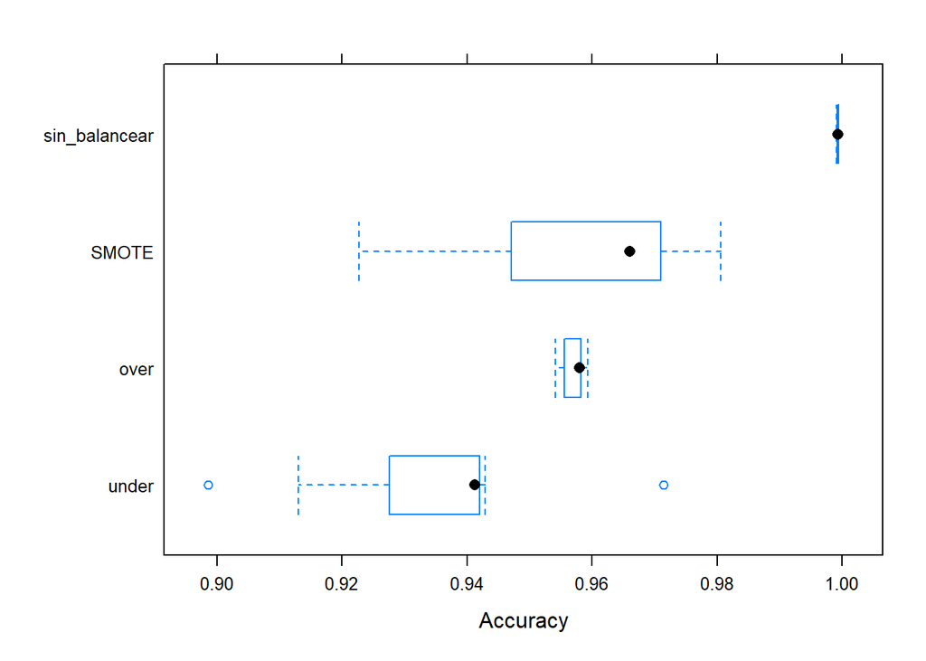

```r
bwplot(comparacion_modelos, metric = "Accuracy")
```

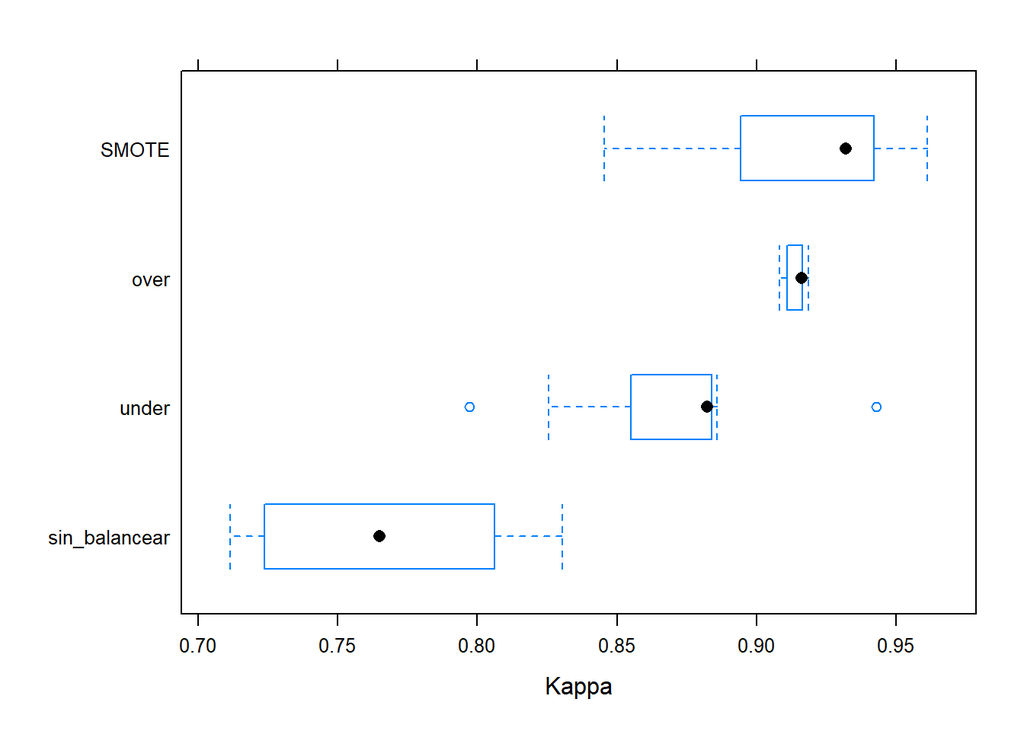

```r
bwplot(comparacion_modelos, metric = "Kappa")
```

Predicción del modelo_orig en la data testing (data original de prueba )

```r
proba.modelo_imbal <- predict(modelo_imbal,
                              newdata = imbal_testing,
                              type = "prob")
head(proba.modelo_imbal) #Probabilidad de No y Si
```

```
##        0        1
## 2  1.000 0.000219
## 5  1.000 0.000110
## 6  1.000 0.000146
## 14 0.999 0.001219
## 15 0.999 0.001347
## 17 0.999 0.000645
```

```r
clase.modelo_imbal <- predict(modelo_imbal,
                              newdata = imbal_testing)
head(clase.modelo_imbal)
```

```
## [1] 0 0 0 0 0 0
## Levels: 0 1
```

```r
result1 <- caret::confusionMatrix(clase.modelo_imbal,
                                  imbal_testing$Class,
                                  positive = "1")

#Todos los Indicadores de desempeño del modelo
result1
```

```
## Confusion Matrix and Statistics
##
##           Reference
## Prediction     0     1
##          0 85273    51
##          1    21    96
##
##                Accuracy : 0.999
##                  95% CI : (0.999, 0.999)
##     No Information Rate : 0.998
##     P-Value [Acc > NIR] : 0.00000000000491
##
##                   Kappa : 0.727
##
##  Mcnemar's Test P-Value : 0.000632
##
##             Sensitivity : 0.65306
##             Specificity : 0.99975
##          Pos Pred Value : 0.82051
##          Neg Pred Value : 0.99940
##              Prevalence : 0.00172
##          Detection Rate : 0.00112
##    Detection Prevalence : 0.00137
##       Balanced Accuracy : 0.82641
##
##        'Positive' Class : 1
##
```

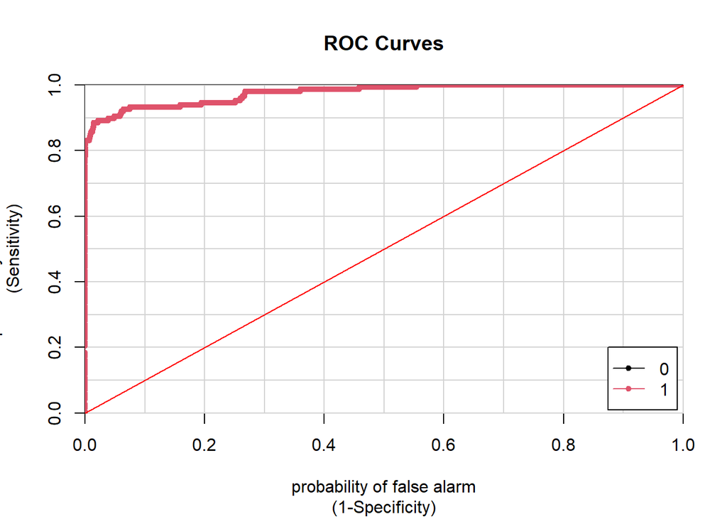

```r
# Curva ROC y AUC
library(caTools)
colAUC(proba.modelo_imbal,
       imbal_testing$Class,
       plotROC = TRUE) -> auc1
abline(0, 1, col = "red")
```

```r
auc1[,1]
```

```
## [1] 0.976
```

Predicción del modelo_under en la data testing (utilizando método Undersampling)

```r
proba.modelo_under <- predict(modelo_under,
                              newdata = imbal_testing,
                              type = "prob")
head(proba.modelo_under)
```

```
##         0      1
## 2  0.9890 0.0110
## 5  0.8908 0.1092
## 6  0.8631 0.1369
## 14 0.8116 0.1884
## 15 0.0196 0.9804
## 17 0.9625 0.0375
```

```r
proba.modelo_under <- proba.modelo_under[, 2]
head(proba.modelo_under)
```

```
## [1] 0.0110 0.1092 0.1369 0.1884 0.9804 0.0375
```

```r
clase.modelo_under <- predict(modelo_under,
                              newdata = imbal_testing )
head(clase.modelo_under)
```

```
## [1] 0 0 0 0 1 0
## Levels: 0 1
```

```r
result2 <- caret::confusionMatrix(clase.modelo_under,
                                  imbal_testing$Class,
                                  positive = "1")

result2
```

```
## Confusion Matrix and Statistics
##
##           Reference
## Prediction     0     1
##          0 79879    10
##          1  5415   137
##
##                Accuracy : 0.937
##                  95% CI : (0.935, 0.938)
##     No Information Rate : 0.998
##     P-Value [Acc > NIR] : 1
##
##                   Kappa : 0.045
##
##  Mcnemar's Test P-Value : <0.0000000000000002
##
##             Sensitivity : 0.93197
##             Specificity : 0.93651
##          Pos Pred Value : 0.02468
##          Neg Pred Value : 0.99987
##              Prevalence : 0.00172
##          Detection Rate : 0.00160
##    Detection Prevalence : 0.06498
##       Balanced Accuracy : 0.93424
##
##        'Positive' Class : 1
##
```

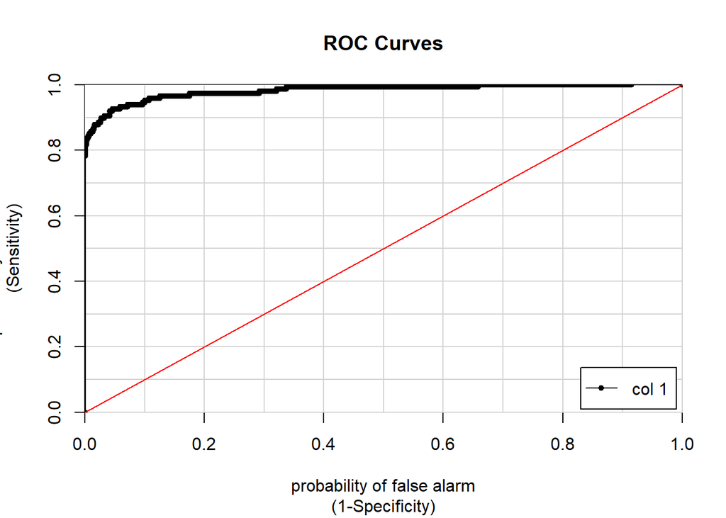

```r
# Curva ROC y AUC
library(caTools)
colAUC(proba.modelo_under,
       imbal_testing$Class,
       plotROC = TRUE) -> auc2
abline(0, 1, col = "red")
```

```r
auc2
```

```
##          [,1]
## 0 vs. 1 0.982
```

Predicción del modelo_over en la data testing (utilizando método OverSampling)

```r
proba.modelo_over <- predict(modelo_over,
                             newdata = imbal_testing,
                             type = "prob")
head(proba.modelo_over)
```

```
##        0      1
## 2  0.925 0.0754
## 5  0.929 0.0715
## 6  0.912 0.0882
## 14 0.755 0.2451
## 15 0.566 0.4340
## 17 0.878 0.1218
```

```r
proba.modelo_over <- proba.modelo_over[, 2]
head(proba.modelo_over)
```

```
## [1] 0.0754 0.0715 0.0882 0.2451 0.4340 0.1218
```

```r
clase.modelo_over <- predict(modelo_over,
                             newdata = imbal_testing )
head(clase.modelo_over)
```

```
## [1] 0 0 0 0 0 0
## Levels: 0 1
```

```r
result3 <- caret::confusionMatrix(clase.modelo_over,
                                  imbal_testing$Class,
                                  positive = "1")

result3
```

```
## Confusion Matrix and Statistics
##
##           Reference
## Prediction     0     1
##          0 83458    13
##          1  1836   134
##
##                Accuracy : 0.978
##                  95% CI : (0.977, 0.979)
##     No Information Rate : 0.998
##     P-Value [Acc > NIR] : 1
##
##                   Kappa : 0.124
##
##  Mcnemar's Test P-Value : <0.0000000000000002
##
##             Sensitivity : 0.91156
##             Specificity : 0.97847
##          Pos Pred Value : 0.06802
##          Neg Pred Value : 0.99984
##              Prevalence : 0.00172
##          Detection Rate : 0.00157
##    Detection Prevalence : 0.02306
##       Balanced Accuracy : 0.94502
##
##        'Positive' Class : 1
##
```

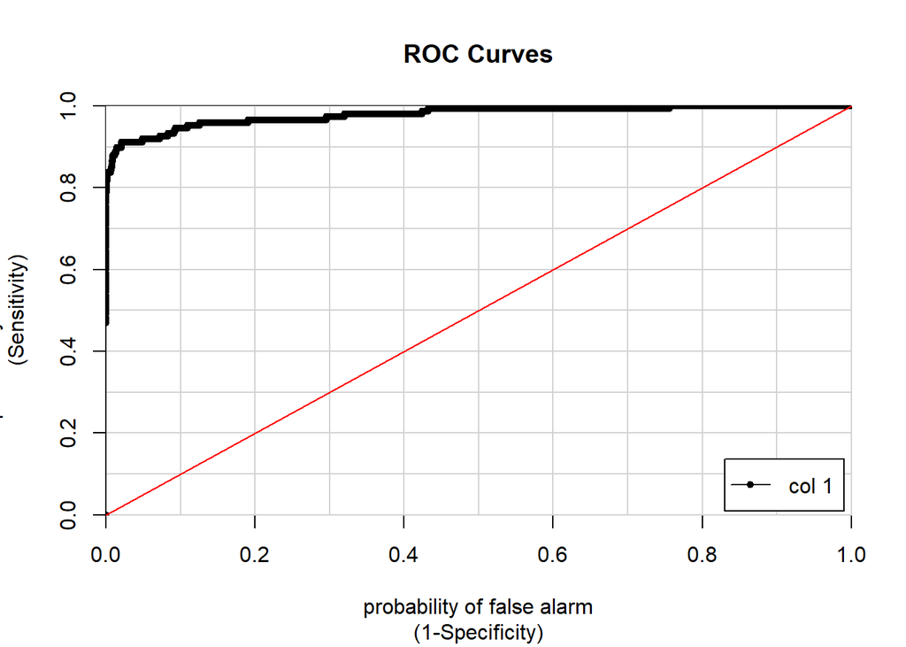

```r
# Curva ROC y AUC
library(caTools)
colAUC(proba.modelo_over,
       imbal_testing$Class,
       plotROC = TRUE) -> auc3
abline(0, 1, col = "red")
```

```r
auc3
```

```
##          [,1]
## 0 vs. 1 0.978
```

Predicción del modelo_smote en la data testing (utilizando método SMOTE)

```r
proba.modelo_smote <- predict(modelo_smote,
                              newdata = imbal_testing,
                              type = "prob")
head(proba.modelo_smote)
```

```
##         0      1
## 2  0.9350 0.0650
## 5  0.9870 0.0130
## 6  0.6558 0.3442
## 14 0.8054 0.1946
## 15 0.0247 0.9753
## 17 0.9228 0.0772
```

```r
proba.modelo_smote <- proba.modelo_smote[, 2]
head(proba.modelo_smote)
```

```
## [1] 0.0650 0.0130 0.3442 0.1946 0.9753 0.0772
```

```r
clase.modelo_smote <- predict(modelo_smote,
                              newdata = imbal_testing )
head(clase.modelo_smote)
```

```
## [1] 0 0 0 0 1 0
## Levels: 0 1
```

```r
result4 <- caret::confusionMatrix(clase.modelo_smote,
                                  imbal_testing$Class,
                                  positive = "1")

result4
```

```
## Confusion Matrix and Statistics
##
##           Reference
## Prediction     0     1
##          0 82962    13
##          1  2332   134
##
##                Accuracy : 0.973
##                  95% CI : (0.971, 0.974)
##     No Information Rate : 0.998
##     P-Value [Acc > NIR] : 1
##
##                   Kappa : 0.1
##
##  Mcnemar's Test P-Value : <0.0000000000000002
##
##             Sensitivity : 0.91156
##             Specificity : 0.97266
##          Pos Pred Value : 0.05434
##          Neg Pred Value : 0.99984
##              Prevalence : 0.00172
##          Detection Rate : 0.00157
##    Detection Prevalence : 0.02886
##       Balanced Accuracy : 0.94211
##
##        'Positive' Class : 1
##
```

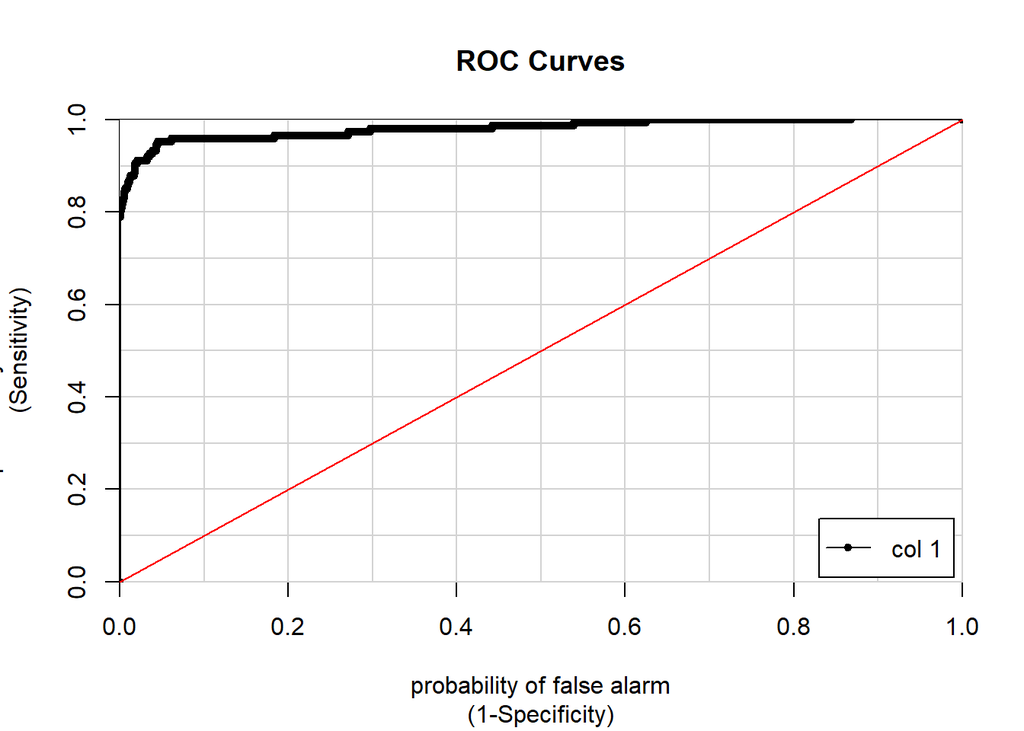

```r
# Curva ROC y AUC
library(caTools)
colAUC(proba.modelo_smote,
       imbal_testing$Class,
       plotROC = TRUE) -> auc4
abline(0, 1, col = "red")
```

```r
auc4
```

```
##         [,1]
## 0 vs. 1 0.98
```

Resumiendo los indicadores de desempeño de los 4 modelos

```r
modelo        <- c("Sin Balancear","Undersampling",
                   "Oversampling","SMOTE")

sensibilidad  <- c(result1$byClass["Sensitivity"],
                   result2$byClass["Sensitivity"],
                   result3$byClass["Sensitivity"],
                   result4$byClass["Sensitivity"])

especificidad <- c(result1$byClass["Specificity"],
                   result2$byClass["Specificity"],
                   result3$byClass["Specificity"],
                   result4$byClass["Specificity"])

accuracy      <- c(result1$overall["Accuracy"],
                   result2$overall["Accuracy"],
                   result3$overall["Accuracy"],
                   result4$overall["Accuracy"])

accuracy_bal    <- c(result1$byClass["Balanced Accuracy"],
                     result2$byClass["Balanced Accuracy"],
                     result3$byClass["Balanced Accuracy"],
                     result4$byClass["Balanced Accuracy"])

auc           <- c(auc1[,1], auc2, auc3, auc4)

comparacion <- data.frame(modelo,
                          sensibilidad,
                          especificidad,
                          accuracy,
                          accuracy_bal,
                          auc
)

# Indicadores de desempeño de los 4 modelos
comparacion
```

```
##          modelo sensibilidad especificidad accuracy accuracy_bal   auc
## 1 Sin Balancear        0.653         1.000    0.999        0.826 0.976
## 2 Undersampling        0.932         0.937    0.937        0.934 0.982
## 3  Oversampling        0.912         0.978    0.978        0.945 0.978
## 4         SMOTE        0.912         0.973    0.973        0.942 0.980
```